# Latihan Pertemuan 4

# PROSES MA(2)

```r
set.seed(1071)
n <- 300
theta1 <- 0.4
theta2 <- 0.6
sigma <- 1

# Data MA(2) manual
e <- rnorm(n + 2, sd = sigma)
y_manual <- e[3:(n + 2)] + theta1 * e[2:(n + 1)] + theta2 * e[1:n]

# Data MA(2) dengan arima.sim
y_arima <- as.numeric(arima.sim(
  model = list(ma = c(theta1, theta2)),
  n = n,
  sd = sigma,
  n.start = 20
))

library(TSA)
```

```r
par(mfrow = c(2, 2))
ts.plot(y_manual, main = "MA(2) Manual")
acf(y_manual, main = "ACF Manual")
pacf(y_manual, main = "PACF Manual")
eacf(y_manual)
```

```
## AR/MA
##   0 1 2 3 4 5 6 7 8 9 10 11 12 13
## 0 x x o o o o o o o o o  o  o  o
## 1 x x x o o o o o o o o  o  o  o
## 2 x x x x o o o o o o o  o  o  o
## 3 x x x x o o o o o o o  o  o  o
## 4 x x o x x o o o o o o  o  o  o
## 5 x x o o x o o o o o o  o  o  o
## 6 x x x o x x o o o o o  o  o  o
## 7 x x o x x x o o x o o  o  o  o
```

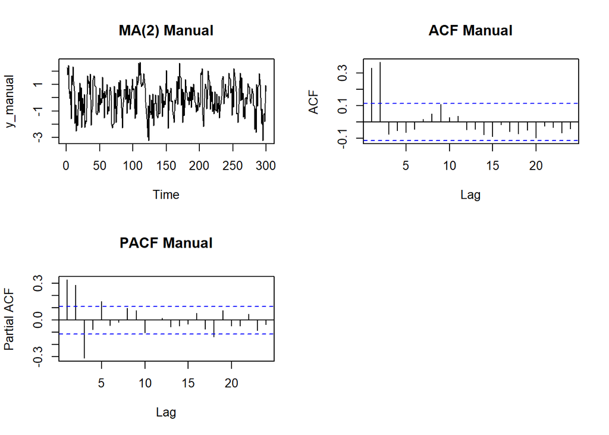

```r
par(mfrow = c(2, 2))
```

```r
ts.plot(y_arima, main = "MA(2) arima.sim")
acf(y_arima, main = "ACF arima.sim")
pacf(y_arima, main = "PACF arima.sim")
eacf(y_arima)
```

```
## AR/MA
##   0 1 2 3 4 5 6 7 8 9 10 11 12 13
## 0 x x o o o o o o o o o  o  x  x
## 1 x x x o o o o o o o o  o  o  o
## 2 x x x x o o o o o o o  o  o  o
## 3 o x x x o o o o o o o  o  o  o
## 4 x x x x o o o o o o o  o  o  o
## 5 o o x x o o o o o o o  o  o  o
## 6 x o x o o o o o o o o  o  o  o
## 7 o x x o x o o o x o o  o  o  o
```

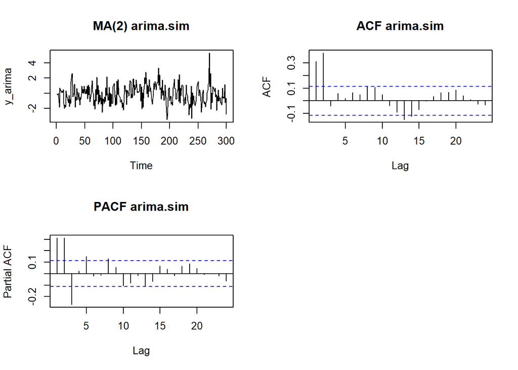

```r
par(mfrow = c(1, 3))
```

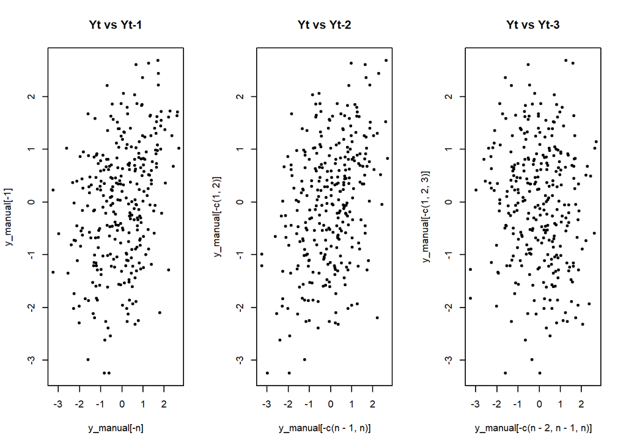

```r
plot(y_manual[-n], y_manual[-1], main = "Yt vs Yt-1", pch = 20)
plot(y_manual[-c(n-1,n)], y_manual[-c(1,2)], main = "Yt vs Yt-2", pch = 20)
plot(y_manual[-c(n-2,n-1,n)], y_manual[-c(1,2,3)], main = "Yt vs Yt-3", pch = 20)
```

```r
acf_manual <- acf(y_manual, plot = FALSE)$acf[1:4]
names(acf_manual) <- paste0("lag", 0:3)
print(acf_manual)
```

```
##        lag0        lag1        lag2        lag3
##  0.32973940  0.36494239 -0.07357509 -0.05087054
```

```r
gamma0 <- sigma^2 * (1 + theta1^2 + theta2^2)
gamma1 <- sigma^2 * (theta1 + theta1 * theta2)
gamma2 <- sigma^2 * theta2
rho_theory <- c(1, gamma1/gamma0, gamma2/gamma0, 0)
names(rho_theory) <- paste0("lag", 0:3)
print(rho_theory)
```

```
##      lag0      lag1      lag2      lag3
## 1.0000000 0.4210526 0.3947368 0.0000000
```

Hasil simulasi menunjukkan bahwa proses MA(2) yang dibangkitkan sudah stasioner. Ini terlihat dari grafik deret waktu yang berfluktuasi di sekitar rata-rata konstan tanpa tren maupun perubahan varians. Plot ACF memotong (cut-off) setelah lag 2, sesuai sifat teori MA(2), sedangkan PACF meredup secara bertahap (tail-off). Tabel EACF menampilkan pola segitiga nol yang menguatkan orde MA(2).

Scatterplot Yₜ terhadap Yₜ₋₁ dan Yₜ₋₂ menunjukkan korelasi positif yang jelas, sementara Yₜ terhadap Yₜ₋₃ nyaris tak berkorelasi, sejalan dengan autokorelasi empiris: sekitar 0.33–0.36 pada lag 1–2 dan mendekati nol pada lag 3. Nilai teoritis (ρ₁≈0.42, ρ₂≈0.39, ρ₃=0) juga sejalan dengan hasil simulasi.